# Classifying Credit Card Fraud

Aditya Kaul

1/25/2018

## Import Libraries

```r
library(dplyr)
library(caret)
library(ggplot2)
library(corrplot)
library(DMwR)
library(e1071)
library(pROC)
library(PRROC)
```

## Import Data

- Store the credit card data in a variable
- Since the response variable is categorical, we change the data type from int to factor

```r
cc_data <- read.csv("creditcard.csv", header = T, sep = ",")
#str(cc_data)

cc_data <- cc_data %>%
  mutate(Class = as.factor(Class))
```

## Check for Class Imbalance

```r
class_0 <- table(cc_data$Class)[1]
class_1 <- table(cc_data$Class)[2]

#Data is highly unbalanced so we need to do some sort of sampling before running the algorithm
class_1*100/nrow(cc_data)
```

```
##         1
## 0.1727486
```

## Correlation Matrix

- Before we train our model we create a correlation matrix
- The matrix helps us find if there are any predictors that are correlated with each other
- If there are predictors that are correlated then we would consider only one of them as a predictor

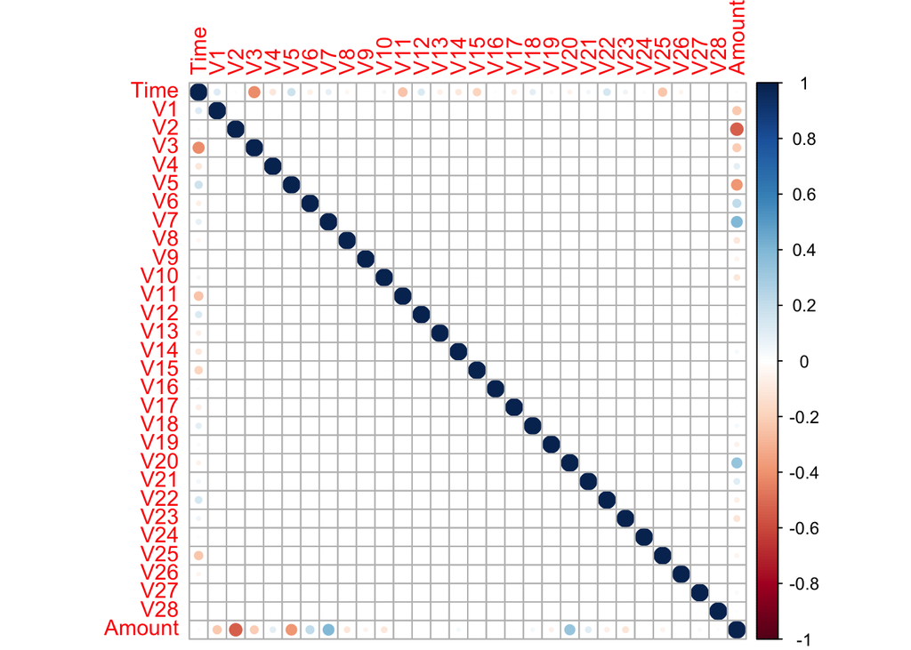

```r
correlated <- cor(cc_data[,1:30])
corrplot(correlated, method = "circle")
```

## Summary of Variables

- We set seed to ensure that we use the same sample each time
- Use the omit command to remove any rows that contain NA values and count the number of rows that we are left with
- We note that there are no missing rows of data and hence do not need to impute any values
- We also check the mean, min and max values of the variables by using the summary function

```r
set.seed(109)
#No null/na values
nrow(na.omit(cc_data))
```

```
## [1] 284807
```

```r
#Normalize and Scale
cc_data_new <- cc_data
summary(cc_data_new[,1:30])
```

```
##       Time              V1                  V2
##  Min.   :     0   Min.   :-56.40751   Min.   :-72.71573
##  1st Qu.: 54202   1st Qu.: -0.92037   1st Qu.: -0.59855
##  Median : 84692   Median :  0.01811   Median :  0.06549
##  Mean   : 94814   Mean   :  0.00000   Mean   :  0.00000
##  3rd Qu.:139320   3rd Qu.:  1.31564   3rd Qu.:  0.80372
##  Max.   :172792   Max.   :  2.45493   Max.   : 22.05773
##        V3                 V4                 V5
##  Min.   :-48.3256   Min.   :-5.68317   Min.   :-113.74331
##  1st Qu.: -0.8904   1st Qu.:-0.84864   1st Qu.:  -0.69160
##  Median :  0.1799   Median :-0.01985   Median :  -0.05434
##  Mean   :  0.0000   Mean   : 0.00000   Mean   :   0.00000
##  3rd Qu.:  1.0272   3rd Qu.: 0.74334   3rd Qu.:   0.61193
##  Max.   :  9.3826   Max.   :16.87534   Max.   :  34.80167
##        V6                 V7                 V8
##  Min.   :-26.1605   Min.   :-43.5572   Min.   :-73.21672
##  1st Qu.: -0.7683   1st Qu.: -0.5541   1st Qu.: -0.20863
##  Median : -0.2742   Median :  0.0401   Median :  0.02236
##  Mean   :  0.0000   Mean   :  0.0000   Mean   :  0.00000
##  3rd Qu.:  0.3986   3rd Qu.:  0.5704   3rd Qu.:  0.32735
##  Max.   : 73.3016   Max.   :120.5895   Max.   : 20.00721
##        V9                 V10                 V11
##  Min.   :-13.43407   Min.   :-24.58826   Min.   :-4.79747
##  1st Qu.: -0.64310   1st Qu.: -0.53543   1st Qu.:-0.76249
##  Median : -0.05143   Median : -0.09292   Median :-0.03276
##  Mean   :  0.00000   Mean   :  0.00000   Mean   : 0.00000
##  3rd Qu.:  0.59714   3rd Qu.:  0.45392   3rd Qu.: 0.73959
##  Max.   : 15.59500   Max.   : 23.74514   Max.   :12.01891
##       V12                V13                V14
##  Min.   :-18.6837   Min.   :-5.79188   Min.   :-19.2143
##  1st Qu.: -0.4056   1st Qu.:-0.64854   1st Qu.: -0.4256
##  Median :  0.1400   Median :-0.01357   Median :  0.0506
##  Mean   :  0.0000   Mean   : 0.00000   Mean   :  0.0000
##  3rd Qu.:  0.6182   3rd Qu.: 0.66251   3rd Qu.:  0.4931
##  Max.   :  7.8484   Max.   : 7.12688   Max.   : 10.5268
##       V15                V16                 V17
##  Min.   :-4.49894   Min.   :-14.12985   Min.   :-25.16280
##  1st Qu.:-0.58288   1st Qu.: -0.46804   1st Qu.: -0.48375
##  Median : 0.04807   Median :  0.06641   Median : -0.06568
##  Mean   : 0.00000   Mean   :  0.00000   Mean   :  0.00000
```

[output cut: 15 more lines]

```
##  Max.   : 27.20284   Max.   : 10.503090   Max.   : 22.52841
##       V24                V25                 V26
##  Min.   :-2.83663   Min.   :-10.29540   Min.   :-2.60455
##  1st Qu.:-0.35459   1st Qu.: -0.31715   1st Qu.:-0.32698
##  Median : 0.04098   Median :  0.01659   Median :-0.05214
##  Mean   : 0.00000   Mean   :  0.00000   Mean   : 0.00000
##  3rd Qu.: 0.43953   3rd Qu.:  0.35072   3rd Qu.: 0.24095
##  Max.   : 4.58455   Max.   :  7.51959   Max.   : 3.51735
##       V27                  V28                Amount
##  Min.   :-22.565679   Min.   :-15.43008   Min.   :    0.00
##  1st Qu.: -0.070840   1st Qu.: -0.05296   1st Qu.:    5.60
##  Median :  0.001342   Median :  0.01124   Median :   22.00
##  Mean   :  0.000000   Mean   :  0.00000   Mean   :   88.35
##  3rd Qu.:  0.091045   3rd Qu.:  0.07828   3rd Qu.:   77.17
##  Max.   : 31.612198   Max.   : 33.84781   Max.   :25691.16
```

## Feature Scaling

- In some machine learning algorithms, if the range of values for a variable vary too much, the objective functions of the algorithm will not work well with the data and our results will be incorrect
- We leverage the preProcess function to transform the data such that we rescale the values to ensure that the mean is at 0 and the range of values for a variable are acceptable such that the objective functions can operate correctly

```r
preprocessparams <- preProcess(cc_data_new[,1:30])
print(preprocessparams)
```

```
## Created from 284807 samples and 30 variables
##
## Pre-processing:
##   - centered (30)
##   - ignored (0)
##   - scaled (30)
```

```r
transformed <- predict(preprocessparams, cc_data_new[,1:30])
summary(transformed)
```

```
##       Time               V1                   V2
##  Min.   :-1.9966   Min.   :-28.798504   Min.   :-44.03521
##  1st Qu.:-0.8552   1st Qu.: -0.469891   1st Qu.: -0.36247
##  Median :-0.2131   Median :  0.009245   Median :  0.03966
##  Mean   : 0.0000   Mean   :  0.000000   Mean   :  0.00000
##  3rd Qu.: 0.9372   3rd Qu.:  0.671693   3rd Qu.:  0.48672
##  Max.   : 1.6421   Max.   :  1.253349   Max.   : 13.35773
##        V3                 V4                 V5
##  Min.   :-31.8717   Min.   :-4.01391   Min.   :-82.40795
##  1st Qu.: -0.5872   1st Qu.:-0.59938   1st Qu.: -0.50107
##  Median :  0.1186   Median :-0.01402   Median : -0.03937
##  Mean   :  0.0000   Mean   : 0.00000   Mean   :  0.00000
##  3rd Qu.:  0.6775   3rd Qu.: 0.52501   3rd Qu.:  0.44335
##  Max.   :  6.1880   Max.   :11.91872   Max.   : 25.21409
##        V6                 V7                  V8
##  Min.   :-19.6360   Min.   :-35.20933   Min.   :-61.30242
##  1st Qu.: -0.5767   1st Qu.: -0.44789   1st Qu.: -0.17468
##  Median : -0.2058   Median :  0.03242   Median :  0.01872
##  Mean   :  0.0000   Mean   :  0.00000   Mean   :  0.00000
##  3rd Qu.:  0.2992   3rd Qu.:  0.46111   3rd Qu.:  0.27408
##  Max.   : 55.0200   Max.   : 97.47807   Max.   : 16.75150
##        V9                 V10                 V11
##  Min.   :-12.22799   Min.   :-22.58187   Min.   :-4.70012
##  1st Qu.: -0.58536   1st Qu.: -0.49173   1st Qu.:-0.74702
##  Median : -0.04681   Median : -0.08533   Median :-0.03209
##  Mean   :  0.00000   Mean   :  0.00000   Mean   : 0.00000
##  3rd Qu.:  0.54353   3rd Qu.:  0.41688   3rd Qu.: 0.72459
##  Max.   : 14.19492   Max.   : 21.80754   Max.   :11.77502
##       V12                V13                V14
##  Min.   :-18.6986   Min.   :-5.81938   Min.   :-20.04425
##  1st Qu.: -0.4059   1st Qu.:-0.65162   1st Qu.: -0.44396
##  Median :  0.1401   Median :-0.01363   Median :  0.05279
##  Mean   :  0.0000   Mean   : 0.00000   Mean   :  0.00000
##  3rd Qu.:  0.6187   3rd Qu.: 0.66565   3rd Qu.:  0.51445
##  Max.   :  7.8547   Max.   : 7.16072   Max.   : 10.98145
##       V15                V16                 V17
##  Min.   :-4.91518   Min.   :-16.12532   Min.   :-29.62640
##  1st Qu.:-0.63681   1st Qu.: -0.53413   1st Qu.: -0.56956
##  Median : 0.05252   Median :  0.07579   Median : -0.07733
##  Mean   : 0.00000   Mean   :  0.00000   Mean   :  0.00000
```

[output cut: 15 more lines]

```
##  Max.   : 37.03465   Max.   : 14.473016   Max.   : 36.07661
##       V24                V25                 V26
##  Min.   :-4.68363   Min.   :-19.75030   Min.   :-5.4011
##  1st Qu.:-0.58547   1st Qu.: -0.60840   1st Qu.:-0.6781
##  Median : 0.06766   Median :  0.03183   Median :-0.1081
##  Mean   : 0.00000   Mean   :  0.00000   Mean   : 0.0000
##  3rd Qu.: 0.72571   3rd Qu.:  0.67280   3rd Qu.: 0.4997
##  Max.   : 7.56967   Max.   : 14.42529   Max.   : 7.2940
##       V27                 V28                Amount
##  Min.   :-55.90650   Min.   :-46.74604   Min.   : -0.35323
##  1st Qu.: -0.17551   1st Qu.: -0.16044   1st Qu.: -0.33084
##  Median :  0.00333   Median :  0.03406   Median : -0.26527
##  Mean   :  0.00000   Mean   :  0.00000   Mean   :  0.00000
##  3rd Qu.:  0.22556   3rd Qu.:  0.23715   3rd Qu.: -0.04472
##  Max.   : 78.31926   Max.   :102.54324   Max.   :102.36206
```

```r
cc_data_final <- transformed
cc_data_final$Class <- cc_data$Class

cc_data_final <- cc_data_final %>%
  mutate(Class = as.factor(Class))
```

## Split the data into training and validation

- Now we split the data into a training set and a validation set with an 80-20 split

```r
#Split into train and test
div <- sample(nrow(cc_data_final), 80 * nrow(cc_data_final)/100, replace = FALSE)
cc_data_train <- cc_data_final[div,]
```

## SMOTE

- Since our data set is unbalanced we will synthetically introduce minority class data and remove some of the majority class data by using the SMOTE technique
- The other techniques that can be used are undersampling, oversampling and ROSE

```r
smote_train <- SMOTE(Class ~ ., data  = cc_data_train, perc.over = 1000, perc.under = 200)
table(smote_train$Class)
```

```
##
##    0    1
## 8120 4466
```

```r
table(cc_data_train$Class)
```

```
##
##      0      1
## 227439    406
```

## K-Fold Cross Validation

```r
train_control <- trainControl(method = "repeatedcv", number = 10, repeats = 5)
```

## Top Feature Selection

- We can randomly select which features are good for our model by simply eyeballing but we can create a subset of variables by also using a random forest that gives us the features that we have used and their score
- It is possible to use all the provided variables in the model but that is not ideal since we want to avoid overfitting
- Include a variable in the model only if adding it improves the score significantly

```r
model <- train(Class ~ ., method = "rf", data = smote_train)
model
```

```
## Random Forest
##
## 12586 samples
##    30 predictor
##     2 classes: '0', '1'
##
## No pre-processing
## Resampling: Bootstrapped (25 reps)
## Summary of sample sizes: 12586, 12586, 12586, 12586, 12586, 12586, ...
## Resampling results across tuning parameters:
##
##   mtry  Accuracy   Kappa
##    2    0.9859626  0.9690551
##   16    0.9874226  0.9723433
##   30    0.9856096  0.9683874
##
## Accuracy was used to select the optimal model using the largest value.
## The final value used for the model was mtry = 16.
```

```r
#typeof(varImp(model))
important_variables <- as.data.frame(varImp(model)[1])
important_variables$variable <- rownames(important_variables)
rownames(important_variables) <- NULL

#str(important_variables)
sorted_variables <- important_variables[order(-important_variables$Overall),]
```

## Training Set - Boosted Logistic Regression

- We leverage the top features from above and use them to train our model - A Boosted Logistic Regression
- Note that we have ONLY used features that were evaluated as highly significant

```r
model_new <- train(Class ~ V14 + V10 + V12 + V4 + V17 + V11, method = "LogitBoost", data = smote_train)
model_new
```

```
## Boosted Logistic Regression
##
## 12586 samples
##     6 predictor
##     2 classes: '0', '1'
##
## No pre-processing
## Resampling: Bootstrapped (25 reps)
## Summary of sample sizes: 12586, 12586, 12586, 12586, 12586, 12586, ...
## Resampling results across tuning parameters:
##
##   nIter  Accuracy   Kappa
##   11     0.9471368  0.8829826
##   21     0.9476153  0.8840258
##   31     0.9477445  0.8844427
##
## Accuracy was used to select the optimal model using the largest value.
## The final value used for the model was nIter = 31.
```

## Validation Set - Boosted Logistic Regression

- Once we train our model we would like to validate its performance by predicting the results for our validation set
- We already know the results for the set but would like to check our models performance for data that it has not seen before
- Note that the threshold for our classifier is kept at 0.5 or 50%
- We will discuss more on how changing the threshold of the classifier impacts our metrics

```r
cc_data_validation <- cc_data_final[-div,]

cc_data_validation$predicted_val <-
  ifelse(as.numeric(predict(model_new, type = "prob", newdata = cc_data_validation)[,2] >= 0.5),1,0)
```

## Output Metrics - Boosted Logistic Regression

- We create a confusion matrix that gives us the true positive, true negative, false positive and false negative values
- Depending on the business question we can define which metric is important to us
- **Recall:** Since our task is to find cases of fraud recall will be an important metric. As a business we would want to capture as many cases of fraud as possible. Even if it means we are accidentally classifying some customers as potential cases of fraud. The risk for the business is higher if someone who was fraudulant escaped us
- **Precision:** This helps us capture cases where we are extremely sure that the potential cases of fraud are definitely going to happen. If our risk is losing customers and we are more concerned with catching cases where fraud will most definitely happen we prefer using precision as the metric. Note that in cases of unbalanced data sets such as the current example our precision will be extremely poor
- **Accuracy:** We can identify how a classifier performs by correctly predicting true positives and true negatives correctly from all the total cases that are present. For an imbalanced dataset accuracy is not a good metric because even if the classifier predicts all the cases as the majority class our metric will still have a high value which is not a good indicator
- **F1 Score:** A harmonic mean of precision and recall. Ideally for a model we would want a good balance between precision and recall and we can achieve that by looking at the F1 score of the classifier
- **ROC:** An ROC curve is a plot that shows the tradeoff between sensitivity and specificity. The closer the curve to the left hand and top border, the better the model performance. The more the area under the curve (AUC) of the model, the better the model
- **PR Curve:** Another alternative to F1 Score is a PR Curve. It helps to show how balanced the precision and recall are. Although for our current case, we are more concerned with getting a better recall score, for a more balanced scenario we would prefer having a PR Curve that gives us the threshold at which we have a stable value of precision and recall
- We mentioned about the threshold of our classifier in the previous section. By default the threshold is 50%
- We can make our model stricter, such that we have better precision by increasing the threshold to greater than 50%
- We can also make our model lenient, that is, reduce the threshold to less than 50% to allow a better value for recall
- Note that depending on the business question that needs to be answered we can vary the threshold to improve precision or recall. However, if we want a balanced model we should keep the threshold at 50%

```r
conf_mat <- table(cc_data_validation$predicted_val, cc_data_validation$Class)

tn <- conf_mat[1]
fp <- conf_mat[2]
fn <- conf_mat[3]
tp <- conf_mat[4]


recall <- tp/(tp + fn)
precision <- tp/(tp + fp)
accuracy <- (tp + tn)/(tn + fp + fn + tp)
f1_score <- (2 * precision * recall)/(precision + recall)

#ROC_val <- roc(cc_data_validation$Class, cc_data_validation$predicted_val, percent = TRUE)
#plot(ROC_val)
#AUC <- auc(roc(cc_data_validation$Class, cc_data_validation$predicted_val))

conf_mat
```

```
##
##         0     1
##   0 55634     4
##   1  1242    82
```

```r
print(paste0("Recall is:",round(recall*100,2),"%"))
```

```
## [1] "Recall is:95.35%"
```

```r
print(paste0("Precision is:",round(precision*100,2),"%"))
```

```
## [1] "Precision is:6.19%"
```

```r
print(paste0("Accuracy is:",round(accuracy*100,2),"%"))
```

```
## [1] "Accuracy is:97.81%"
```

```r
print(paste0("F1 Score is:",round(f1_score*100,2),"%"))
```

```
## [1] "F1 Score is:11.63%"
```

```r
#print(paste0("AUC is:",round(AUC*100,2),"%"))



probs <- cc_data_validation$predicted_val
fg <- probs[cc_data_validation$Class == 1]
bg <- probs[cc_data_validation$Class == 0]

roc <- roc.curve(scores.class0 = fg, scores.class1 = bg, curve = T)
plot(roc)
```

[output not shown]

```r
pr <- pr.curve(scores.class0 = fg, scores.class1 = bg, curve = T)
plot(pr)
```

[output not shown]

## Training Set - Boosted Logistic Regression

- Since we performed feature selection by first leveraging a random forest, we only chose a subset of all the variables that were provided to us
- In the below model we have used all the available variables to see if there is an improvement in the model by leveraging everything that is provided to us
- If we check the output metrics of the below model with all variables, we see that there is a decrease values for all our metrics. We are overfitting the model and hence it is better to use features that are non correlated to each other as well as only features that impact the model significantly

```r
model_new_full <- train(Class ~ ., method = "LogitBoost", data = smote_train)
model_new_full
```

```
## Boosted Logistic Regression
##
## 12586 samples
##    30 predictor
##     2 classes: '0', '1'
##
## No pre-processing
## Resampling: Bootstrapped (25 reps)
## Summary of sample sizes: 12586, 12586, 12586, 12586, 12586, 12586, ...
## Resampling results across tuning parameters:
##
##   nIter  Accuracy   Kappa
##   11     0.9494025  0.8888417
##   21     0.9522318  0.8951860
##   31     0.9547586  0.9006676
##
## Accuracy was used to select the optimal model using the largest value.
## The final value used for the model was nIter = 31.
```

## Validation Set - Boosted Logistic Regression

```r
cc_data_validation_full <- cc_data_final[-div,]

cc_data_validation_full$predicted_val <-
  ifelse(as.numeric(predict(model_new_full, type = "prob", newdata = cc_data_validation)[,2] >= 0.5),1,0)
```

## Output Metrics - Boosted Logistic Regression

```r
conf_mat_full <- table(cc_data_validation_full$predicted_val, cc_data_validation_full$Class)

tn_full <- conf_mat_full[1]
fp_full <- conf_mat_full[2]
fn_full <- conf_mat_full[3]
tp_full <- conf_mat_full[4]


recall_full <- tp_full/(tp_full + fn_full)
precision_full <- tp_full/(tp_full + fp_full)
accuracy_full <- (tp_full + tn_full)/(tn_full + fp_full + fn_full + tp_full)
f1_score_full <- (2 * precision_full * recall_full)/(precision_full + recall_full)

#ROC_val <- roc(cc_data_validation$Class, cc_data_validation$predicted_val, percent = TRUE)
#plot(ROC_val)
#AUC <- auc(roc(cc_data_validation$Class, cc_data_validation$predicted_val))

conf_mat_full
```

```
##
##         0     1
##   0 55207     6
##   1  1669    80
```

```r
print(paste0("Recall is:",round(recall_full*100,2),"%"))
```

```
## [1] "Recall is:93.02%"
```

```r
print(paste0("Precision is:",round(precision_full*100,2),"%"))
```

```
## [1] "Precision is:4.57%"
```

```r
print(paste0("Accuracy is:",round(accuracy_full*100,2),"%"))
```

```
## [1] "Accuracy is:97.06%"
```

```r
print(paste0("F1 Score is:",round(f1_score_full*100,2),"%"))
```

```
## [1] "F1 Score is:8.72%"
```

```r
#print(paste0("AUC is:",round(AUC_full*100,2),"%"))



probs_full <- cc_data_validation_full$predicted_val
fg_full <- probs[cc_data_validation_full$Class == 1]
bg_full <- probs[cc_data_validation_full$Class == 0]

roc_full <- roc.curve(scores.class0 = fg_full, scores.class1 = bg_full, curve = T)
plot(roc_full)
```

[output not shown]

```r
pr_full <- pr.curve(scores.class0 = fg_full, scores.class1 = bg_full, curve = T)
plot(pr_full)
```

[output not shown]

## Complex Models - SVM with Weights

- Once we use the more generalized model, we then try to see if we can improve the model metrics further by using a more complex/flexible model
- It is important to note that a more complex model will result in a better training result but the test error might be even higher if the model is overfitting. A complex model tends to fit closer to our training data and hence might even fit to the noise that is present in our data
- Although a more generalized model does not give us perfect metrics, it is a much safer choice that we can consider with more confidence
- This being said, a generalized model is not necessarily the solution every time as a simple line might not be the best classifier. We might indeed need a more flexible model in certain cases

```r
model_new_full <- train(Class ~ V14 + V10 + V12 + V4 + V17 + V11, method = "svmLinearWeights", data = smote_train)
model_new_full
```

```
## Linear Support Vector Machines with Class Weights
##
## 12586 samples
##     6 predictor
##     2 classes: '0', '1'
##
## No pre-processing
## Resampling: Bootstrapped (25 reps)
## Summary of sample sizes: 12586, 12586, 12586, 12586, 12586, 12586, ...
## Resampling results across tuning parameters:
##
##   cost  weight  Accuracy   Kappa
##   0.25  1       0.9498450  0.8877756
##   0.25  2       0.9508840  0.8911739
##   0.25  3       0.9488945  0.8878834
##   0.50  1       0.9500355  0.8882223
##   0.50  2       0.9508926  0.8912186
##   0.50  3       0.9486862  0.8874769
##   1.00  1       0.9500701  0.8883081
##   1.00  2       0.9509180  0.8912818
##   1.00  3       0.9485742  0.8872673
##
## Accuracy was used to select the optimal model using the largest value.
## The final values used for the model were cost = 1 and weight = 2.
```

## Validation Set - SVM with Weights

```r
cc_data_validation_full <- cc_data_final[-div,]

cc_data_validation_full$predicted_val <- predict(model_new_full, newdata = cc_data_validation)
```

## Output Metrics - SVM with Weights

```r
conf_mat_full <- table(cc_data_validation_full$predicted_val, cc_data_validation_full$Class)

tn_full <- conf_mat_full[1]
fp_full <- conf_mat_full[2]
fn_full <- conf_mat_full[3]
tp_full <- conf_mat_full[4]


recall_full <- tp_full/(tp_full + fn_full)
precision_full <- tp_full/(tp_full + fp_full)
accuracy_full <- (tp_full + tn_full)/(tn_full + fp_full + fn_full + tp_full)
f1_score_full <- (2 * precision_full * recall_full)/(precision_full + recall_full)

#ROC_val <- roc(cc_data_validation$Class, cc_data_validation$predicted_val, percent = TRUE)
#plot(ROC_val)
#AUC <- auc(roc(cc_data_validation$Class, cc_data_validation$predicted_val))

conf_mat_full
```

```
##
##         0     1
##   0 55737     6
##   1  1139    80
```

```r
print(paste0("Recall is:",round(recall_full*100,2),"%"))
```

```
## [1] "Recall is:93.02%"
```

```r
print(paste0("Precision is:",round(precision_full*100,2),"%"))
```

```
## [1] "Precision is:6.56%"
```

```r
print(paste0("Accuracy is:",round(accuracy_full*100,2),"%"))
```

```
## [1] "Accuracy is:97.99%"
```

```r
print(paste0("F1 Score is:",round(f1_score_full*100,2),"%"))
```

```
## [1] "F1 Score is:12.26%"
```

```r
#print(paste0("AUC is:",round(AUC_full*100,2),"%"))



probs_full <- cc_data_validation_full$predicted_val
fg_full <- probs[cc_data_validation_full$Class == 1]
bg_full <- probs[cc_data_validation_full$Class == 0]

roc_full <- roc.curve(scores.class0 = fg_full, scores.class1 = bg_full, curve = T)
plot(roc_full)
```

[output not shown]

```r
pr_full <- pr.curve(scores.class0 = fg_full, scores.class1 = bg_full, curve = T)
plot(pr_full)
```

[output not shown]

## Training Set - Random Forest

```r
model_new_full <- train(Class ~ V14 + V10 + V12 + V4 + V17 + V11, method = "rf", data = smote_train)
model_new_full
```

```
## Random Forest
##
## 12586 samples
##     6 predictor
##     2 classes: '0', '1'
##
## No pre-processing
## Resampling: Bootstrapped (25 reps)
## Summary of sample sizes: 12586, 12586, 12586, 12586, 12586, 12586, ...
## Resampling results across tuning parameters:
##
##   mtry  Accuracy   Kappa
##   2     0.9758474  0.9466154
##   4     0.9750429  0.9449422
##   6     0.9726708  0.9397746
##
## Accuracy was used to select the optimal model using the largest value.
## The final value used for the model was mtry = 2.
```

## Validation Set - Random Forest

```r
cc_data_validation_full <- cc_data_final[-div,]

cc_data_validation_full$predicted_val <-
  ifelse(as.numeric(predict(model_new_full, type = "prob", newdata = cc_data_validation)[,2] >= 0.5),1,0)
```

## Output Metrics - Random Forest

```r
conf_mat_full <- table(cc_data_validation_full$predicted_val, cc_data_validation_full$Class)

tn_full <- conf_mat_full[1]
fp_full <- conf_mat_full[2]
fn_full <- conf_mat_full[3]
tp_full <- conf_mat_full[4]


recall_full <- tp_full/(tp_full + fn_full)
precision_full <- tp_full/(tp_full + fp_full)
accuracy_full <- (tp_full + tn_full)/(tn_full + fp_full + fn_full + tp_full)
f1_score_full <- (2 * precision_full * recall_full)/(precision_full + recall_full)

#ROC_val <- roc(cc_data_validation$Class, cc_data_validation$predicted_val, percent = TRUE)
#plot(ROC_val)
#AUC <- auc(roc(cc_data_validation$Class, cc_data_validation$predicted_val))

conf_mat_full
```

```
##
##         0     1
##   0 56513     6
##   1   363    80
```

```r
print(paste0("Recall is:",round(recall_full*100,2),"%"))
```

```
## [1] "Recall is:93.02%"
```

```r
print(paste0("Precision is:",round(precision_full*100,2),"%"))
```

```
## [1] "Precision is:18.06%"
```

```r
print(paste0("Accuracy is:",round(accuracy_full*100,2),"%"))
```

```
## [1] "Accuracy is:99.35%"
```

```r
print(paste0("F1 Score is:",round(f1_score_full*100,2),"%"))
```

```
## [1] "F1 Score is:30.25%"
```

```r
#print(paste0("AUC is:",round(AUC_full*100,2),"%"))



probs_full <- cc_data_validation_full$predicted_val
fg_full <- probs[cc_data_validation_full$Class == 1]
bg_full <- probs[cc_data_validation_full$Class == 0]

roc_full <- roc.curve(scores.class0 = fg_full, scores.class1 = bg_full, curve = T)
plot(roc_full)
```

[output not shown]

```r
pr_full <- pr.curve(scores.class0 = fg_full, scores.class1 = bg_full, curve = T)
plot(pr_full)
```

[output not shown]

## Training Set - Naive Bayes

```r
model_new_full <- train(Class ~ V14 + V10 + V12 + V4 + V17 + V11, method = "nb", data = smote_train)
model_new_full
```

```
## Naive Bayes
##
## 12586 samples
##     6 predictor
##     2 classes: '0', '1'
##
## No pre-processing
## Resampling: Bootstrapped (25 reps)
## Summary of sample sizes: 12586, 12586, 12586, 12586, 12586, 12586, ...
## Resampling results across tuning parameters:
##
##   usekernel  Accuracy   Kappa
##   FALSE      0.9407403  0.8672640
##    TRUE      0.9427511  0.8710342
##
## Tuning parameter 'fL' was held constant at a value of 0
## Tuning
##  parameter 'adjust' was held constant at a value of 1
## Accuracy was used to select the optimal model using the largest value.
## The final values used for the model were fL = 0, usekernel = TRUE
##  and adjust = 1.
```

## Validation Set - Naive Bayes

```r
cc_data_validation_full <- cc_data_final[-div,]

cc_data_validation_full$predicted_val <-
  ifelse(as.numeric(predict(model_new_full, type = "prob", newdata = cc_data_validation)[,2] >= 0.5),1,0)
```

## Output Metrics - Naive Bayes

```r
conf_mat_full <- table(cc_data_validation_full$predicted_val, cc_data_validation_full$Class)

tn_full <- conf_mat_full[1]
fp_full <- conf_mat_full[2]
fn_full <- conf_mat_full[3]
tp_full <- conf_mat_full[4]


recall_full <- tp_full/(tp_full + fn_full)
precision_full <- tp_full/(tp_full + fp_full)
accuracy_full <- (tp_full + tn_full)/(tn_full + fp_full + fn_full + tp_full)
f1_score_full <- (2 * precision_full * recall_full)/(precision_full + recall_full)

#ROC_val <- roc(cc_data_validation$Class, cc_data_validation$predicted_val, percent = TRUE)
#plot(ROC_val)
#AUC <- auc(roc(cc_data_validation$Class, cc_data_validation$predicted_val))

conf_mat_full
```

```
##
##         0     1
##   0 56496    10
##   1   380    76
```

```r
print(paste0("Recall is:",round(recall_full*100,2),"%"))
```

```
## [1] "Recall is:88.37%"
```

```r
print(paste0("Precision is:",round(precision_full*100,2),"%"))
```

```
## [1] "Precision is:16.67%"
```

```r
print(paste0("Accuracy is:",round(accuracy_full*100,2),"%"))
```

```
## [1] "Accuracy is:99.32%"
```

```r
print(paste0("F1 Score is:",round(f1_score_full*100,2),"%"))
```

```
## [1] "F1 Score is:28.04%"
```

```r
#print(paste0("AUC is:",round(AUC_full*100,2),"%"))



probs_full <- cc_data_validation_full$predicted_val
fg_full <- probs[cc_data_validation_full$Class == 1]
bg_full <- probs[cc_data_validation_full$Class == 0]

roc_full <- roc.curve(scores.class0 = fg_full, scores.class1 = bg_full, curve = T)
plot(roc_full)
```

[output not shown]

```r
pr_full <- pr.curve(scores.class0 = fg_full, scores.class1 = bg_full, curve = T)
plot(pr_full)
```

[output not shown]